# 2022 - Data Analytics for Immersive Environments - CA4 - RDBMS & Linear Regression Project

Part 1 - Generate and Populate Database

Joe O’Regan

2023-01-11

# Repo Link

https://github.com/joeaoregan/2022_DAIE_CA4_JOR1

# ER Diagram

[figure not shown]

# Create Tables

## Create or recreate the sqlite file

```r
# if the sqlite file exists already delete it
if (file.exists("daie_ca4_data.sqlite"))
  file.remove("daie_ca4_data.sqlite")

# create the sqlite file
conn <- dbConnect(RSQLite::SQLite(), "daie_ca4_data.sqlite")
```

## Create the tables

### Asset

Show each table cropped from the main ER Diagram using magick library. Only dimensions and offset change for each cropped table, so this code is shown once.

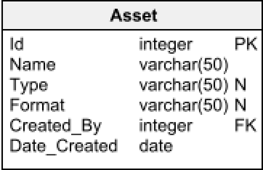

```r
er_img <- image_read("daie_ca4_er_diagram.png")
# cropped image dimension offset by location (in pixels)
# (newXdimension x newYdimension + Xlocation + Ylocation)
asset_img = image_scale(image_crop(er_img, "181x117+184+155"),
                        ifelse(is_html_output(), scale_html, scale_pdf))
asset_img
```

Describes a single electronic resource produced by one or more work items

- **Id:** Unique identifier for each row
- **Name:** Description of the asset
- **Type:** Short description of type of asset (Not mandatory)
- **Format:** Short description of format of asset (Not mandatory)
- **Created_By:** Team member who created the asset
- **Date_Created:** Date the asset was created

**Primary Key(s):** Id (auto increments)

**Foreign Key(s):** Created_By (Team_Member.Id)

Create the Asset table. Automatically increment the primary key. Id, Name, Created_By, and Date_created are mandatory fields.

```r
# create tables
dbExecute(conn, "CREATE TABLE Asset (
    Id integer NOT NULL CONSTRAINT Asset_pk PRIMARY KEY AUTOINCREMENT,
    Name varchar(50) NOT NULL,
    Type varchar(50),
    Format varchar(50),
    Created_By integer NOT NULL,
    Date_Created date NOT NULL,
    CONSTRAINT Asset_Team_Member FOREIGN KEY (Created_By)
    REFERENCES Team_Member (Id)
);")
```

### Asset_Work_Items

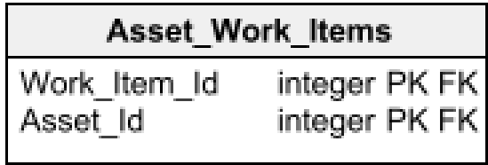

Assets are made up of work items

- **Work_Item_Id:** Id for work items used to create the asset
- **Asset_Id:** Id of the asset

**Primary Key(s):** Composite. Work_Item_Id + Asset_Id

**Foreign Key(s):** Work_Item_Id (Work_Item.Id), Asset_Id (Asset.Id)

```r
dbExecute(conn, "CREATE TABLE Asset_Work_Items (
    Work_Item_Id integer NOT NULL,
    Asset_Id integer NOT NULL,
    CONSTRAINT Asset_Work_Items_pk PRIMARY KEY (Work_Item_Id,Asset_Id),
    CONSTRAINT Asset_Work_Item_Work_Item FOREIGN KEY (Work_Item_Id)
    REFERENCES Work_Item (Id),
    CONSTRAINT Asset_Work_Items_Asset FOREIGN KEY (Asset_Id)
    REFERENCES Asset (Id)
);")
```

### Collection

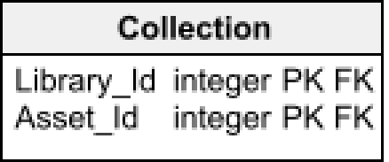

Collection of assets

- **Library_Id:** Unique reference for a collection of assets
- **Asset_Id:** Unique reference of the asset that make up a collection

**Primary Key(s):** Composite. Library_Id + Asset_Id

**Foreign Key(s):** Library_Id (Library.Id), Asset_Id (Asset.Id)

```r
dbExecute(conn, "CREATE TABLE Collection (
    Library_Id integer NOT NULL,
    Asset_Id integer NOT NULL,
    CONSTRAINT Collection_Id PRIMARY KEY (Library_Id,Asset_Id),
    CONSTRAINT Collection_Asset FOREIGN KEY (Asset_Id)
    REFERENCES Asset (Id),
    CONSTRAINT Collection_Library FOREIGN KEY (Library_Id)
    REFERENCES Library (Id)
);")
```

### Library

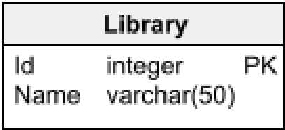

Describes a collection of available assets

- **Id:** Unique reference for each collection in Library
- **Name:** Description of library collection

**Primary Key(s):** Id

**Foreign Key(s):** Id (Collection.Library_Id)

```r
dbExecute(conn, "CREATE TABLE Library (
    Id integer NOT NULL CONSTRAINT Library_pk PRIMARY KEY AUTOINCREMENT,
    Name varchar(50) NOT NULL
);")
```

### Project

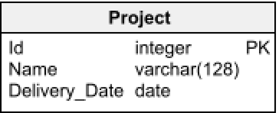

Describes a project being produced, timeline, and team involved

- **Id:** Unique reference for each project
- **Name:** Description of Project
- **Delivery_Date:** Date project is due to finish

**Primary Key(s):** Id

**Foreign Key(s):** Id (Project_Team.Project_Id). Each Project has multiple Team Members.

```r
dbExecute(conn, "CREATE TABLE Project (
    Id integer NOT NULL CONSTRAINT Project_pk PRIMARY KEY,
    Name varchar(128) NOT NULL,
    Delivery_Date date NOT NULL
);")
```

### Project_Team

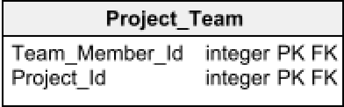

Each project has team members assigned to it

- **Team_Member_Id:** Unique reference for each Team Member
- **Project_Id:** Id of Project

**Primary Key(s):** Composite. Team_Member_Id + Project_Id

**Foreign Key(s):** Team_Member_Id (Team_Member.Id), Project_Id (Project.Id). Each Project has multiple Team Members. Each team member can work on 1 or more projects.

```r
dbExecute(conn, "CREATE TABLE Project_Team (
    Team_Member_Id integer NOT NULL,
    Project_Id integer NOT NULL,
    CONSTRAINT Project_Team_Id PRIMARY KEY (Project_Id,Team_Member_Id),
    CONSTRAINT Team_Team_Member FOREIGN KEY (Team_Member_Id)
    REFERENCES Team_Member (Id),
    CONSTRAINT Team_Project FOREIGN KEY (Project_Id)
    REFERENCES Project (Id)
);")
```

### Role

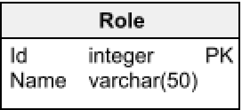

Each team member has a role (and only 1 role as I already used 10 tables)

- **Id:** Unique reference for role
- **Name:** Role description

**Primary Key(s):** Id

**Foreign Key(s):** Id (Team_Member.Role_Id). Each team member has 1 role for projects.

Additional fields that could be added in this table are salary for the role, seniority, and description. I meant to add a description field here.

```r
dbExecute(conn, "CREATE TABLE Role (
    Id integer NOT NULL CONSTRAINT Role_pk PRIMARY KEY AUTOINCREMENT,
    Name varchar(50) NOT NULL
);")
```

### Status

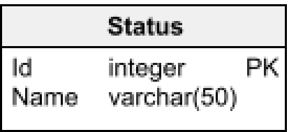

Work items have a progress status

- **Id:** Unique reference for status
- **Name:** Status description

**Primary Key(s):** Id

**Foreign Key(s):** Id (Work_Item.Stats_Id). Each work item has a status (To Do, In Progress, Review, Done).

An additional field that could be added in this table is description. I meant to add this after moving status to its own table, but forgot to come back to it.

```r
dbExecute(conn, "CREATE TABLE Status (
    Id integer NOT NULL CONSTRAINT Status_pk PRIMARY KEY AUTOINCREMENT,
    Name varchar(50) NOT NULL
);")
```

### Team_Member

Describes an individual on the team

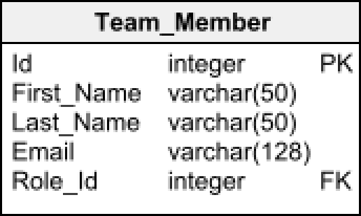

- **Id:** Unique reference for team member
- **First_Name:** Team Member first name
- **Last_Name:** Team Member last name
- **Email:** Team Member email
- **Role_Id:** Team members role for projects

**Primary Key(s):** Id

**Foreign Key(s):** Id (Project_Team.Team_Member_Id, Work_Item.Assigned_To), Role_Id (Role.Id). Each Team Member has a role for projects. Each project team has team members. Each work item can be assigned to a team member.

```r
dbExecute(conn, "CREATE TABLE Team_Member (
    Id integer NOT NULL CONSTRAINT Team_Member_pk PRIMARY KEY AUTOINCREMENT,
    First_Name varchar(50) NOT NULL,
    Last_Name varchar(50) NOT NULL,
    Email varchar(128) NOT NULL,
    Role_Id integer NOT NULL,
    CONSTRAINT Team_Member_Email_AK UNIQUE (Email),
    CONSTRAINT Team_Member_Role FOREIGN KEY (Role_Id)
    REFERENCES Role (Id)
);")
```

### Work_Item

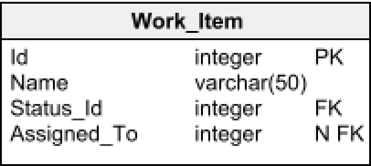

Describes smallest parcel of work resulting in a testable output

- **Id:** Unique reference for work item.
- **Name:** Description of work item.
- **Status_Id:** Work item has as status (To Do, In Progress, Review, Done).
- **Assigned_To:** Work items can be assigned to team members.

**Primary Key(s):** Id

**Foreign Key(s):** Id (Asset_Work_Items.Work_Item.Id), Status_Id (Status.Id), Assigned_To (Team_Member.Id). Each work item can be assigned to a team member. Each work Item has a status. Assets are made of work items.

```r
dbExecute(conn, "CREATE TABLE Work_Item (
    Id integer NOT NULL CONSTRAINT Work_Item_pk PRIMARY KEY AUTOINCREMENT,
    Name varchar(50) NOT NULL,
    Status_Id integer NOT NULL,
    Assigned_To integer NOT NULL,
    CONSTRAINT Work_Item_Statuses FOREIGN KEY (Status_Id)
    REFERENCES Status (Id),
    CONSTRAINT Work_Item_Team_Member FOREIGN KEY (Assigned_To)
    REFERENCES Team_Member (Id)
);")
```

## Show tables in database

```r
dbListTables(conn)
```

```
##  [1] "Asset"            "Asset_Work_Items" "Collection"       "Library"
##  [5] "Project"          "Project_Team"     "Role"             "Status"
##  [9] "Team_Member"      "Work_Item"        "sqlite_sequence"
```

## Data format function

Function to format tables for HTML and PDF output. Display tables using knitr library’s kable function and kableExtra to format tables.

```r
data_format.function <- function(data, capt) {
  data %>%
    {
      #if (is_html_output()) { # if the output is HTML add class attribute
      #  kbl(., table.attr='class="table-striped table-hover"', caption = capt)}
      #else if (is_latex_output()) { # if the output is PDF ignore class attribute
        kbl(., caption = capt)
      #}
    } %>% # pdf output keep tables in position
      #kable_styling("striped", ifelse(is_html_output(),"hover","hold_position"),
      kable_styling(bootstrap_options = c("striped", "hover", "condensed", "HOLD_position"),
                    latex_options = c("striped","HOLD_position"),
                    stripe_color="#AAFFAA",
                    htmltable_class="table-striped table-hover") %>%
        row_spec(0, background = "#1AE81A")
}
```

## Insert Data

### Status

```r
dbListFields(conn, "Status")
```

```
## [1] "Id"   "Name"
```

Insert table data (using DBI library dbExecute function):

```r
dbExecute(conn, "INSERT INTO Status ('Name') VALUES ('To Do');")
dbExecute(conn, "INSERT INTO Status ('Name') VALUES ('In Progress');")
dbExecute(conn, "INSERT INTO Status ('Name') VALUES ('Review');")
dbExecute(conn, "INSERT INTO Status ('Name') VALUES ('Done');")
```

Display table data (using knitr library kable function):

```r
status_data <- dbGetQuery(conn, "SELECT * FROM Status;")
data_format.function(status_data, "Status Table")
```

Status Table

| Id | Name |
| --- | --- |
| 1 | To Do |
| 2 | In Progress |
| 3 | Review |
| 4 | Done |

### Role

```r
dbListFields(conn, "Role")
```

```
## [1] "Id"   "Name"
```

Insert table data:

```r
dbExecute(conn, "INSERT INTO Role ('Name') VALUES ('Project Manager');")
dbExecute(conn, "INSERT INTO Role ('Name') VALUES ('Programmer');")
dbExecute(conn, "INSERT INTO Role ('Name') VALUES ('Tester');")
dbExecute(conn, "INSERT INTO Role ('Name') VALUES ('Artist');")
dbExecute(conn, "INSERT INTO Role ('Name') VALUES ('3D Modeller');")
dbExecute(conn, "INSERT INTO Role ('Name') VALUES ('Environment Modeller');")
dbExecute(conn, "INSERT INTO Role ('Name') VALUES ('Animator');")
dbExecute(conn, "INSERT INTO Role ('Name') VALUES ('Shading Artist');")
dbExecute(conn, "INSERT INTO Role ('Name') VALUES ('Concept Artist');")
```

Display table data:

```r
role_data <- dbGetQuery(conn, "SELECT * FROM Role;")
data_format.function(role_data, "Role Table")
```

Role Table

| Id | Name |
| --- | --- |
| 1 | Project Manager |
| 2 | Programmer |
| 3 | Tester |
| 4 | Artist |
| 5 | 3D Modeller |
| 6 | Environment Modeller |
| 7 | Animator |
| 8 | Shading Artist |
| 9 | Concept Artist |

### Team_Member

```r
dbListFields(conn, "Team_Member")
```

```
## [1] "Id"         "First_Name" "Last_Name"  "Email"      "Role_Id"
```

Insert table data:

```r
dbExecute(conn, "INSERT INTO Team_Member ('First_Name', 'Last_Name', 'Email', 'Role_Id')
          VALUES ('Joe', 'O''Regan', 'joe.oregan@daie.ca4', 2);")
dbExecute(conn, "INSERT INTO Team_Member ('First_Name', 'Last_Name', 'Email', 'Role_Id')
          VALUES ('Derp', 'McDerp', 'derpmcderp@daie.ca4', 1);")
dbExecute(conn, "INSERT INTO Team_Member ('First_Name', 'Last_Name', 'Email', 'Role_Id')
          VALUES ('Herpderp', 'Derpderpenson', 'hd.derpderpenson@daie.ca4', 3);")
dbExecute(conn, "INSERT INTO Team_Member ('First_Name', 'Last_Name', 'Email', 'Role_Id')
          VALUES ('Herpa', 'Derpderp', 'herpa.derpderp@daie.ca4', 4);")
dbExecute(conn, "INSERT INTO Team_Member ('First_Name', 'Last_Name', 'Email', 'Role_Id')
          VALUES ('De', 'Rpderp', 'de.rpderp@daie.ca4', 5);")
dbExecute(conn, "INSERT INTO Team_Member ('First_Name', 'Last_Name', 'Email', 'Role_Id')
          VALUES ('Pred', 'Prehpred', 'predprehpred@daie.ca4', 6);")
dbExecute(conn, "INSERT INTO Team_Member ('First_Name', 'Last_Name', 'Email', 'Role_Id')
          VALUES ('Derpa', 'Derpa', 'derpaderpa@daie.ca4', 9);")
dbExecute(conn, "INSERT INTO Team_Member ('First_Name', 'Last_Name', 'Email', 'Role_Id')
          VALUES ('Herpa', 'Derpa', 'herpaderpa@daie.ca4', 8);")
dbExecute(conn, "INSERT INTO Team_Member ('First_Name', 'Last_Name', 'Email', 'Role_Id')
          VALUES ('HerpaDerpa', 'McDerpa', 'herpaderpa.mcderpa@daie.ca4', 7);")
dbExecute(conn, "INSERT INTO Team_Member ('First_Name', 'Last_Name', 'Email', 'Role_Id')
          VALUES ('Joe', 'Derp', 'j.derp@daie.ca4', 2);")
dbExecute(conn, "INSERT INTO Team_Member ('First_Name', 'Last_Name', 'Email', 'Role_Id')
          VALUES ('Jon', 'Herpaderp', 'jherpaderp@daie.ca4', 7);")
dbExecute(conn, "INSERT INTO Team_Member ('First_Name', 'Last_Name', 'Email', 'Role_Id')
          VALUES ('Joblot', 'O''Stuff', 'joblot.ostuff@daie.ca4', 3);")
dbExecute(conn, "INSERT INTO Team_Member ('First_Name', 'Last_Name', 'Email', 'Role_Id')
          VALUES ('Joderp', 'Herpderpenson', 'j.herpderpenson@daie.ca4', 4);")
dbExecute(conn, "INSERT INTO Team_Member ('First_Name', 'Last_Name', 'Email', 'Role_Id')
          VALUES ('Jo', 'McQueryfiller', 'j.mcqueryfiller@daie.ca4', 1);")
```

Display table data:

```r
team_member_data <- dbGetQuery(conn, "SELECT * FROM Team_Member;")
data_format.function(team_member_data, "Team Member Table")
```

Team Member Table

| Id | First_Name | Last_Name | Email | Role_Id |
| --- | --- | --- | --- | --- |
| 1 | Joe | O’Regan | joe.oregan@daie.ca4 | 2 |
| 2 | Derp | McDerp | derpmcderp@daie.ca4 | 1 |
| 3 | Herpderp | Derpderpenson | hd.derpderpenson@daie.ca4 | 3 |
| 4 | Herpa | Derpderp | herpa.derpderp@daie.ca4 | 4 |
| 5 | De | Rpderp | de.rpderp@daie.ca4 | 5 |
| 6 | Pred | Prehpred | predprehpred@daie.ca4 | 6 |
| 7 | Derpa | Derpa | derpaderpa@daie.ca4 | 9 |
| 8 | Herpa | Derpa | herpaderpa@daie.ca4 | 8 |
| 9 | HerpaDerpa | McDerpa | herpaderpa.mcderpa@daie.ca4 | 7 |
| 10 | Joe | Derp | j.derp@daie.ca4 | 2 |
| 11 | Jon | Herpaderp | jherpaderp@daie.ca4 | 7 |
| 12 | Joblot | O’Stuff | joblot.ostuff@daie.ca4 | 3 |
| 13 | Joderp | Herpderpenson | j.herpderpenson@daie.ca4 | 4 |
| 14 | Jo | McQueryfiller | j.mcqueryfiller@daie.ca4 | 1 |

### Work_Item

```r
dbListFields(conn, "Work_Item")
```

```
## [1] "Id"          "Name"        "Status_Id"   "Assigned_To"
```

Insert table data:

```r
dbExecute(conn, "INSERT INTO Work_Item ('Name', 'Status_Id', 'Assigned_To')
          VALUES ('Art Thingy', 2, 4);")
dbExecute(conn, "INSERT INTO Work_Item ('Name', 'Status_Id', 'Assigned_To')
          VALUES ('Art Test Thingy', 3, 3);")
dbExecute(conn, "INSERT INTO Work_Item ('Name', 'Status_Id', 'Assigned_To')
          VALUES ('Environment Model Thingy', 2, 6);")
dbExecute(conn, "INSERT INTO Work_Item ('Name', 'Status_Id', 'Assigned_To')
          VALUES ('Art Concept Thingy', 4, 7);")
dbExecute(conn, "INSERT INTO Work_Item ('Name', 'Status_Id', 'Assigned_To')
          VALUES ('Art Shading Thingy', 4, 8);")
dbExecute(conn, "INSERT INTO Work_Item ('Name', 'Status_Id', 'Assigned_To')
          VALUES ('Random 3D Model', 2, 5);")
dbExecute(conn, "INSERT INTO Work_Item ('Name', 'Status_Id', 'Assigned_To')
          VALUES ('3D Model Test Obj', 2, 3);")
dbExecute(conn, "INSERT INTO Work_Item ('Name', 'Status_Id', 'Assigned_To')
          VALUES ('Random Blueprint', 2, 1);")
dbExecute(conn, "INSERT INTO Work_Item ('Name', 'Status_Id', 'Assigned_To')
          VALUES ('Blueprint Thingy', 2, 2);")
dbExecute(conn, "INSERT INTO Work_Item ('Name', 'Status_Id', 'Assigned_To')
          VALUES ('Blueprint Test', 3, 2);")
dbExecute(conn, "INSERT INTO Work_Item ('Name', 'Status_Id', 'Assigned_To')
          VALUES ('Art Test', 1, 12);")
dbExecute(conn, "INSERT INTO Work_Item ('Name', 'Status_Id', 'Assigned_To')
          VALUES ('Query Model Thingy', 3, 11);")
dbExecute(conn, "INSERT INTO Work_Item ('Name', 'Status_Id', 'Assigned_To')
          VALUES ('Another Test', 4, 13);")
```

Display table data:

```r
work_item_data <- dbGetQuery(conn, "SELECT * FROM Work_Item;")
data_format.function(work_item_data, "Work Item Table")
```

Work Item Table

| Id | Name | Status_Id | Assigned_To |
| --- | --- | --- | --- |
| 1 | Art Thingy | 2 | 4 |
| 2 | Art Test Thingy | 3 | 3 |
| 3 | Environment Model Thingy | 2 | 6 |
| 4 | Art Concept Thingy | 4 | 7 |
| 5 | Art Shading Thingy | 4 | 8 |
| 6 | Random 3D Model | 2 | 5 |
| 7 | 3D Model Test Obj | 2 | 3 |
| 8 | Random Blueprint | 2 | 1 |
| 9 | Blueprint Thingy | 2 | 2 |
| 10 | Blueprint Test | 3 | 2 |
| 11 | Art Test | 1 | 12 |
| 12 | Query Model Thingy | 3 | 11 |
| 13 | Another Test | 4 | 13 |

### Project

```r
dbListFields(conn, "Project")
```

```
## [1] "Id"            "Name"          "Delivery_Date"
```

Insert table data:

```r
dbExecute(conn, "INSERT INTO Project ('Name', 'Delivery_Date')
          VALUES ('Art Proj', '2023-01-11');")
dbExecute(conn, "INSERT INTO Project ('Name', 'Delivery_Date')
          VALUES ('DAIE CA4', '2023-01-20');")
dbExecute(conn, "INSERT INTO Project ('Name', 'Delivery_Date')
          VALUES ('New Project', '2023-01-24');")
dbExecute(conn, "INSERT INTO Project ('Name', 'Delivery_Date')
          VALUES ('Old Project', '2022-12-14');")
dbExecute(conn, "INSERT INTO Project ('Name', 'Delivery_Date')
          VALUES ('Christmas 2022 Project', '2022-12-25');")
dbExecute(conn, "INSERT INTO Project ('Name', 'Delivery_Date')
          VALUES ('Date Range Project', '2023-01-17');")
dbExecute(conn, "INSERT INTO Project ('Name', 'Delivery_Date')
          VALUES ('Another Date Range Project', '2023-02-01');")
dbExecute(conn, "INSERT INTO Project ('Name', 'Delivery_Date')
          VALUES ('Project Filler', '2023-03-01');")
dbExecute(conn, "INSERT INTO Project ('Name', 'Delivery_Date')
          VALUES ('Derp Project', '2023-03-17');")
dbExecute(conn, "INSERT INTO Project ('Name', 'Delivery_Date')
          VALUES ('Hmmm I Ran Out of Names', '2023-01-20');")
```

Display table data:

```r
project_data <- dbGetQuery(conn, "SELECT * FROM Project;")
data_format.function(project_data, "Project Table")
```

Project Table

| Id | Name | Delivery_Date |
| --- | --- | --- |
| 1 | Art Proj | 2023-01-11 |
| 2 | DAIE CA4 | 2023-01-20 |
| 3 | New Project | 2023-01-24 |
| 4 | Old Project | 2022-12-14 |
| 5 | Christmas 2022 Project | 2022-12-25 |
| 6 | Date Range Project | 2023-01-17 |
| 7 | Another Date Range Project | 2023-02-01 |
| 8 | Project Filler | 2023-03-01 |
| 9 | Derp Project | 2023-03-17 |
| 10 | Hmmm I Ran Out of Names | 2023-01-20 |

### Project_Team

```r
dbListFields(conn, "Project_Team")
```

```
## [1] "Team_Member_Id" "Project_Id"
```

Insert table data:

```r
dbExecute(conn, "INSERT INTO Project_Team ('Team_Member_Id', 'Project_Id') VALUES (1, 1);")
dbExecute(conn, "INSERT INTO Project_Team ('Team_Member_Id', 'Project_Id') VALUES (2, 1);")
dbExecute(conn, "INSERT INTO Project_Team ('Team_Member_Id', 'Project_Id') VALUES (3, 1);")
dbExecute(conn, "INSERT INTO Project_Team ('Team_Member_Id', 'Project_Id') VALUES (4, 1);")
dbExecute(conn, "INSERT INTO Project_Team ('Team_Member_Id', 'Project_Id') VALUES (5, 1);")
dbExecute(conn, "INSERT INTO Project_Team ('Team_Member_Id', 'Project_Id') VALUES (2, 2);")
dbExecute(conn, "INSERT INTO Project_Team ('Team_Member_Id', 'Project_Id') VALUES (6, 2);")
dbExecute(conn, "INSERT INTO Project_Team ('Team_Member_Id', 'Project_Id') VALUES (7, 2);")
dbExecute(conn, "INSERT INTO Project_Team ('Team_Member_Id', 'Project_Id') VALUES (8, 2);")
dbExecute(conn, "INSERT INTO Project_Team ('Team_Member_Id', 'Project_Id') VALUES (9, 2);")
dbExecute(conn, "INSERT INTO Project_Team ('Team_Member_Id', 'Project_Id') VALUES (2, 3);")
dbExecute(conn, "INSERT INTO Project_Team ('Team_Member_Id', 'Project_Id') VALUES (10, 3);")
dbExecute(conn, "INSERT INTO Project_Team ('Team_Member_Id', 'Project_Id') VALUES (11, 3);")
dbExecute(conn, "INSERT INTO Project_Team ('Team_Member_Id', 'Project_Id') VALUES (14, 4);")
dbExecute(conn, "INSERT INTO Project_Team ('Team_Member_Id', 'Project_Id') VALUES (12, 4);")
dbExecute(conn, "INSERT INTO Project_Team ('Team_Member_Id', 'Project_Id') VALUES (13, 5);")
dbExecute(conn, "INSERT INTO Project_Team ('Team_Member_Id', 'Project_Id') VALUES (14, 6);")
dbExecute(conn, "INSERT INTO Project_Team ('Team_Member_Id', 'Project_Id') VALUES (14, 7);")
```

Display table data:

```r
project_team_data <- dbGetQuery(conn, "SELECT * FROM Project_Team;")
data_format.function(project_team_data, "Project Team Table")
```

Project Team Table

| Team_Member_Id | Project_Id |
| --- | --- |
| 1 | 1 |
| 2 | 1 |
| 3 | 1 |
| 4 | 1 |
| 5 | 1 |
| 2 | 2 |
| 6 | 2 |
| 7 | 2 |
| 8 | 2 |
| 9 | 2 |
| 2 | 3 |
| 10 | 3 |
| 11 | 3 |
| 14 | 4 |
| 12 | 4 |
| 13 | 5 |
| 14 | 6 |
| 14 | 7 |

### Asset

```r
dbListFields(conn, "Asset")
```

```
## [1] "Id"           "Name"         "Type"         "Format"       "Created_By"
## [6] "Date_Created"
```

Insert table data:

```r
dbExecute(conn, "INSERT INTO Asset ('Name', 'Type', 'Format', 'Created_By', 'Date_Created')
          VALUES ('Random Blueprint Asset', 'Combination of Blueprints', 'Zip file', 1, '2023-01-11');")
dbExecute(conn, "INSERT INTO Asset ('Name', 'Created_By', 'Date_Created')
          VALUES ('Random Art Asset', 4, '2023-01-10');")
dbExecute(conn, "INSERT INTO Asset ('Name', 'Created_By', 'Date_Created')
          VALUES ('Art Asset Thingy', 4, '2023-01-10');")
dbExecute(conn, "INSERT INTO Asset ('Name', 'Type', 'Created_By', 'Date_Created')
          VALUES ('Environment Asset Thingy', 'Tree for use in Environment',4, '2023-01-02');")
```

Display table data:

```r
asset_data <- dbGetQuery(conn, "SELECT * FROM Asset;")
data_format.function(asset_data, "Asset Table")
```

Asset Table

| Id | Name | Type | Format | Created_By | Date_Created |
| --- | --- | --- | --- | --- | --- |
| 1 | Random Blueprint Asset | Combination of Blueprints | Zip file | 1 | 2023-01-11 |
| 2 | Random Art Asset | NA | NA | 4 | 2023-01-10 |
| 3 | Art Asset Thingy | NA | NA | 4 | 2023-01-10 |
| 4 | Environment Asset Thingy | Tree for use in Environment | NA | 4 | 2023-01-02 |

### Asset_Work_Items

```r
dbListFields(conn, "Asset_Work_Items")
```

```
## [1] "Work_Item_Id" "Asset_Id"
```

Insert table data:

```r
dbExecute(conn, "INSERT INTO Asset_Work_Items ('Work_Item_Id', 'Asset_Id') VALUES (8, 1);")
dbExecute(conn, "INSERT INTO Asset_Work_Items ('Work_Item_Id', 'Asset_Id') VALUES (9, 1);")
dbExecute(conn, "INSERT INTO Asset_Work_Items ('Work_Item_Id', 'Asset_Id') VALUES (10, 1);")
dbExecute(conn, "INSERT INTO Asset_Work_Items ('Work_Item_Id', 'Asset_Id') VALUES (1, 2);")
dbExecute(conn, "INSERT INTO Asset_Work_Items ('Work_Item_Id', 'Asset_Id') VALUES (2, 2);")
dbExecute(conn, "INSERT INTO Asset_Work_Items ('Work_Item_Id', 'Asset_Id') VALUES (4, 3);")
dbExecute(conn, "INSERT INTO Asset_Work_Items ('Work_Item_Id', 'Asset_Id') VALUES (5, 3);")
dbExecute(conn, "INSERT INTO Asset_Work_Items ('Work_Item_Id', 'Asset_Id') VALUES (3, 4);")
dbExecute(conn, "INSERT INTO Asset_Work_Items ('Work_Item_Id', 'Asset_Id') VALUES (6, 4);")
dbExecute(conn, "INSERT INTO Asset_Work_Items ('Work_Item_Id', 'Asset_Id') VALUES (7, 4);")
```

Display table data:

```r
asset_work_items_data <- dbGetQuery(conn, "SELECT * FROM Asset_Work_Items;")
data_format.function(asset_work_items_data, "Asset Work Items Table")
```

Asset Work Items Table

| Work_Item_Id | Asset_Id |
| --- | --- |
| 8 | 1 |
| 9 | 1 |
| 10 | 1 |
| 1 | 2 |
| 2 | 2 |
| 4 | 3 |
| 5 | 3 |
| 3 | 4 |
| 6 | 4 |
| 7 | 4 |

### Collection

```r
dbListFields(conn, "Collection")
```

```
## [1] "Library_Id" "Asset_Id"
```

Insert table data:

```r
dbExecute(conn, "INSERT INTO Collection ('Library_Id', 'Asset_Id') VALUES (1, 1);")
dbExecute(conn, "INSERT INTO Collection ('Library_Id', 'Asset_Id') VALUES (2, 2);")
dbExecute(conn, "INSERT INTO Collection ('Library_Id', 'Asset_Id') VALUES (2, 3);")
dbExecute(conn, "INSERT INTO Collection ('Library_Id', 'Asset_Id') VALUES (3, 4);")
```

Display table data:

```r
collection_data <- dbGetQuery(conn, "SELECT * FROM Collection;")
data_format.function(collection_data, "Collection Table")
```

Collection Table

| Library_Id | Asset_Id |
| --- | --- |
| 1 | 1 |
| 2 | 2 |
| 2 | 3 |
| 3 | 4 |

### Library

```r
dbListFields(conn, "Library")
```

```
## [1] "Id"   "Name"
```

Insert table data:

```r
dbExecute(conn, "INSERT INTO Library ('Name') VALUES ('Programming');")
dbExecute(conn, "INSERT INTO Library ('Name') VALUES ('Models');")
dbExecute(conn, "INSERT INTO Library ('Name') VALUES ('Scenery');")
dbExecute(conn, "INSERT INTO Library ('Name') VALUES ('Characters');")
```

Display table data:

```r
library_data <- dbGetQuery(conn, "SELECT * FROM Library;")
data_format.function(library_data, "Library Table")
```

Library Table

| Id | Name |
| --- | --- |
| 1 | Programming |
| 2 | Models |
| 3 | Scenery |
| 4 | Characters |

## Disconnect Database

```r
dbDisconnect(conn)
```